# Viz con ggplot2

# Paso 0

Instala

```r
install.packages("ggplot2")
install.packages("GDAdata")
install.packages("gridExtra")
install.packages("meta")
```

# Intro - Viz

La graficación es una manera eficiente de resumir, y mostrar información. Es fundamental entender el contexto de negocio y de la generación de los datos para tener más información con respecto a lo que se está graficando.

> John Tukey resume el propósito de la visualización de datos en cuatro frases:
> 1. Las gráficas son para análsisis cualitativos o descriptivos y quizá semi cuantitativos, nunca para análisis profundo cuantitativo (las tablas son mejores para esta tarea).
> 2. Las gráficas son para realizar comparaciones (en el tiempo, entre grupos), no para describir cantidades particulares.
> 3. Las gráficas son para impactar (visualmente, para sorprender, para transmitir información), pero casi nunca sirven para reflejar patrones escondidos en los datos.
> 4. Las gráficas deberían de reportar un análisis de datos trabajado, fino y cuidadoso. Jamás deben de reemplazar el análisis. Las gráficas están para fortalecer el análisis, no para fundamentarlo y los gráficos finales en un análisis deben reflejar el análisis realizado.

# La gramática de las gráficas

Es una herramienta que nos permite (Wickham, 2010)

- Describir los componentes de una gráfica en forma concisa
- Ir más allá de los nombres de la gráfica (e.g. scatterplot, boxplot, etc.)
- Entender la estructura detrás de los gráficos estadísticos

La gramática le da reglas al lenguaje y es un sistema formal para generar enunciados.

Proporciona una gramática para gráficos que permite describir y construir una gran cantidad de gráficos estadísticos.

Wickham implementa esta gramática en el paquete `ggplot2` de `R`, como un sistema consistente para describir y construir gráficas.

Para conocer los fundamentos teoricos de ggplot puedes ver “The Layered Grammar of Graphics”, http://vita.had.co.nz/papers/layered-grammar.pdf

Es parte del tidyverse, por lo que ya lo tienes instalado si realizaste `install.packages("tidyverse")`. Si quieres solo ggplot, debes instalar `install.packages("ggplot2")`.

La implementación en capas, permite que los usuarios no se limiten únicamente a los gráficos específicos que se implementan paquete a paquete sino que puedan realizar tantos gráficos como este lenguaje de gráficos permita.

# Base plotting vs. ggplot

Observemos una gráfica utilizando la base `diamonds` en donde graficamos en el eje $x$ el carataje de diamantes y en el eje $y$ su precio:

```r
data(diamonds, package = "ggplot2")
str(diamonds)
```

```
## Classes 'tbl_df', 'tbl' and 'data.frame':    53940 obs. of  10 variables:
##  $ carat  : num  0.23 0.21 0.23 0.29 0.31 0.24 0.24 0.26 0.22 0.23 ...
##  $ cut    : Ord.factor w/ 5 levels "Fair"<"Good"<..: 5 4 2 4 2 3 3 3 1 3 ...
##  $ color  : Ord.factor w/ 7 levels "D"<"E"<"F"<"G"<..: 2 2 2 6 7 7 6 5 2 5 ...
##  $ clarity: Ord.factor w/ 8 levels "I1"<"SI2"<"SI1"<..: 2 3 5 4 2 6 7 3 4 5 ...
##  $ depth  : num  61.5 59.8 56.9 62.4 63.3 62.8 62.3 61.9 65.1 59.4 ...
##  $ table  : num  55 61 65 58 58 57 57 55 61 61 ...
##  $ price  : int  326 326 327 334 335 336 336 337 337 338 ...
##  $ x      : num  3.95 3.89 4.05 4.2 4.34 3.94 3.95 4.07 3.87 4 ...
##  $ y      : num  3.98 3.84 4.07 4.23 4.35 3.96 3.98 4.11 3.78 4.05 ...
##  $ z      : num  2.43 2.31 2.31 2.63 2.75 2.48 2.47 2.53 2.49 2.39 ...
```

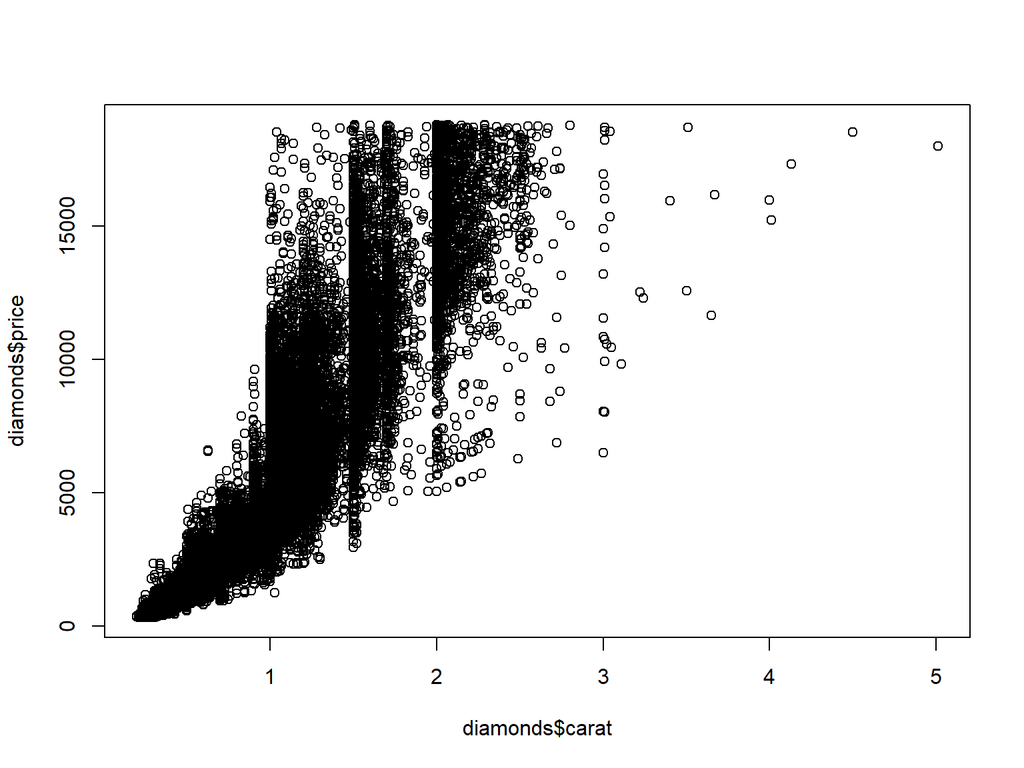

```r
plot(diamonds$carat, diamonds$price)
```

Ese mismo gráfico, podemos realizarlo con la función `qplot` del paquete`ggplot`:

```r
qplot(data = diamonds, x = carat, y = price, geom = "point")
```

En donde especificamos que la variable `carat` en la base `diamonds` mapea al eje $x$, la variable `price` en la misma base al eje $y$ y queremos que la geometría sea de puntos.

Observa que la estética de la gráfica generada con la función `plot` es un poco distinta a la generada con `qplot` (función que utiliza `ggplot`). Verifica la clase que tiene cada objeto, en el primer caso no tiene y en el segundo tenemos un objeto de clase `ggplot` que tiene atributos y que podemos guardar en un objeto.

# ggplot

Los componentes de la gramática de gráficas específica para `ggplot` son:

1. Una o más capas donde cada cuál tiene:
   1. Datos
   2. Mapeo estético de los datos (*aesthetic mappings*)
   3. Un objeto geométrico
   4. Una transformación estadística
   5. Ajustes en las posiciones de los objetos
2. Una escala para cada estética
3. Un sistema de coordenadas
4. Una especificación de facetas

Al graficar en `ggplot` se tiene control sobre todos estos elementos:

```r
ggplot() +
  layer( # una capa
    data = diamonds, # datos
    mapping = aes(x = carat, y = price), # mapeo estético
    geom = "point", # geometría
    stat = "identity", # transformación estadística
    position = "identity" # ajuste en posición de objetos
    ) +
  scale_y_continuous() + # Escala para estética continua en y
  scale_x_continuous() + # Escala para estética continua en x
  coord_cartesian() # Sistema de coordenadas
```

`ggplot` implementa también una serie de `defaults` que facilitan la escritura de nuevas gráficas pues no es necesario especificar cada uno de los detalles al agregar una capa. Por tanto, es posible escribir el mismo gráfico haciendo uso de esos `defaults`:

```r
ggplot(diamonds, aes(carat, price)) + geom_point()
```

# Características importantes

Los componentes de una gráfica son ortogonales:

```
- Cambiar uno no debe romper los otros
- Una configuración distinta de componentes es válida
- Puedes construir mayor complejidad agregando capas
```

# Las capas

`ggplot` produce un objeto que se puede convertir en una gráfica. Es decir, `R` sabe cómo convertirlo en una gráfica.

Este objeto está formado por capas, mismas que tienen sus entradas (*inputs*) particulares y que comparten argumentos del gráfico `base` generado por la función `ggplot()`. Con el operador `+` se van agregando las distintas capas al mismo objeto.

Así como en otros casos, el objeto en `R` puede ser guardado en una variable, se le puede imprimir, se le puede guardar como imagen de diferentes formatos, o se puede guardar en una lista o en un `Rdata`.

## Componentes de una capa

### Datos y mapa estético

Permite mapear las columnas del `data.frame` de entrada a los aspectos de la gráfica.

Es decir,

- las coordenadas $x$, $y$
- los grupos (definidos por otra variable)
- el tamaño
- el color
- el relleno

Para ejemplificar, generamos una variable $x$ que proviene de dos distribuciones normales: mil realizaciones $N(0, 1)$ y mil $N(3, 1)$. Asignamos un grupo a las primeras mil y otro a la segunda.

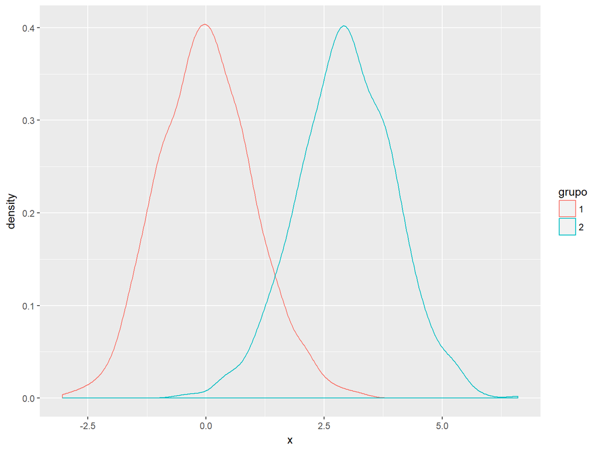

```r
mix2norm <- data.frame(x  = c(rnorm(1000), rnorm(1000, 3)),
                       grupo = as.factor(rep(c(1,2),each=1000)))

ggplot(mix2norm, aes(x=x, color = grupo)) + geom_density()
```

### Transformaciones estadísticas

Ésta puede ser, por ejemplo, un resumen de la entrada (*input*) recibido; se especifica vía el comando `stat`. Ejemplos:

- binning
- smoothing
- boxplot
- identity

Utilizamos, por ejemplo, la transformación *bin*, misma que se especifica en el objeto geométrico:

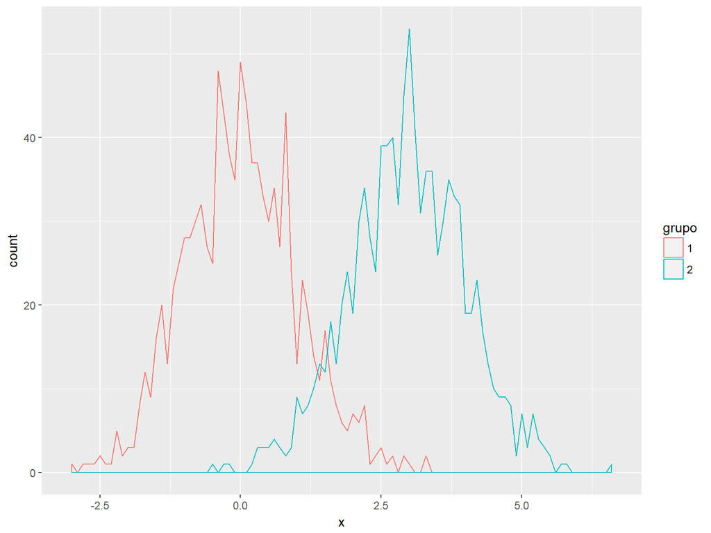

```r
ggplot(mix2norm, aes(x=x, color = grupo)) +
  geom_density(stat = "bin", binwidth = 0.1)
```

La transformación utilizada tiene asociada parámetros como lo es el tamaño en el que deben realizarse los colapsos de la variable categórica (*binwidth*).

### El objeto geométrico

Esto permite especificar el tipo de gráfico a crear. Se especifica con la `geom`. Se define de acuerdo a su dimensión, es decir,

- `0-dim`: puntos, texto
- `1-dim`: líneas
- `2-dim`: polígonos, intervalos

Otras geometrías incluyen:

- `geom_hist`
- `geom_bar`
- `geom_contour`
- `geom_line`
- `geom_density`

Además, se puede cambiar la transformación estadística manteniendo la geometría fijada. Al ejemplo anterior, le agregamos una transformación estadística dentro del objeto geométrico con el parámetro `adjust`.

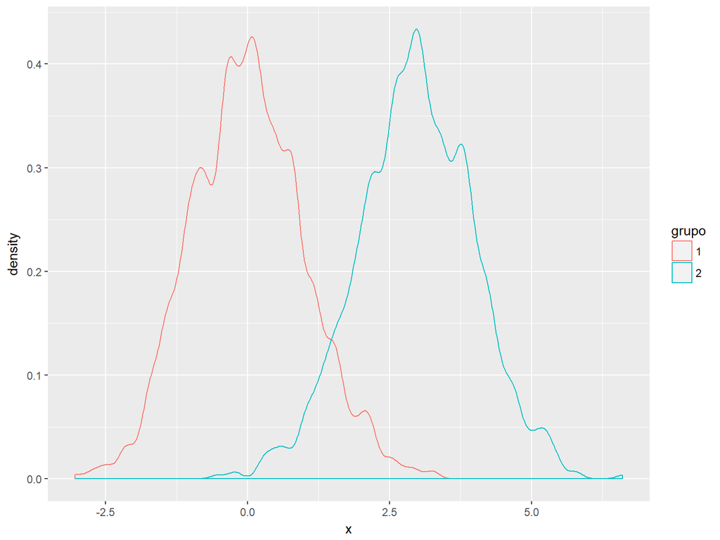

```r
ggplot(mix2norm, aes(x = x, color = grupo)) + geom_density(adjust = 1/2)
```

En este caso, estamos pidiendo la mitad del tamaño del bin que se calcula en forma algorítmica por el paquete.

Viceversa, puede cambiarse la geometría pero mantener la transformación estadística.

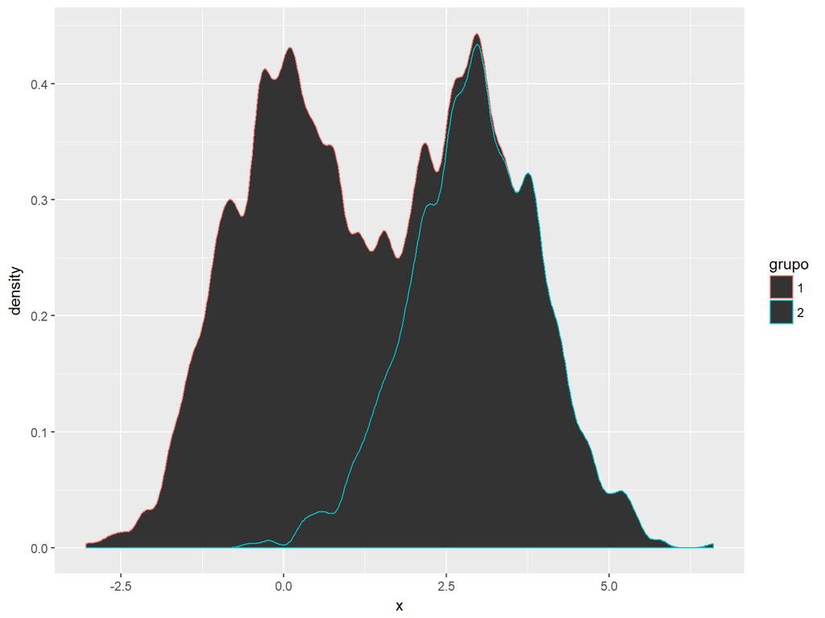

```r
ggplot(mix2norm, aes(x = x, color = grupo)) + stat_density(adjust = 1/2)
```

# Ejercicio - Diamonds

```r
diamonds
```

```
## # A tibble: 53,940 x 10
##    carat cut       color clarity depth table price     x     y     z
##    <dbl> <ord>     <ord> <ord>   <dbl> <dbl> <int> <dbl> <dbl> <dbl>
##  1 0.230 Ideal     E     SI2      61.5  55.0   326  3.95  3.98  2.43
##  2 0.210 Premium   E     SI1      59.8  61.0   326  3.89  3.84  2.31
##  3 0.230 Good      E     VS1      56.9  65.0   327  4.05  4.07  2.31
##  4 0.290 Premium   I     VS2      62.4  58.0   334  4.20  4.23  2.63
##  5 0.310 Good      J     SI2      63.3  58.0   335  4.34  4.35  2.75
##  6 0.240 Very Good J     VVS2     62.8  57.0   336  3.94  3.96  2.48
##  7 0.240 Very Good I     VVS1     62.3  57.0   336  3.95  3.98  2.47
##  8 0.260 Very Good H     SI1      61.9  55.0   337  4.07  4.11  2.53
##  9 0.220 Fair      E     VS2      65.1  61.0   337  3.87  3.78  2.49
## 10 0.230 Very Good H     VS1      59.4  61.0   338  4.00  4.05  2.39
## # ... with 53,930 more rows
```

1. Genera una gráfica con la función `ggplot` en donde los datos sea la base `diamonds` y la estética sea $x = price$. Especifica como geometría una densidad usando `+ stat_density()`.
2. Cambia el color y el relleno de la geometría a gris (`grey50`).

Dentro de stat_density especifica `fill = "grey50"`. Haz lo mismo para especificar `color` dentro de `stat_density`.

3. Cambia la geometría a `ribbon`, cambiando `stat_density` de la siguiente forma:

`stat_density(aes(ymax = ..density.., ymin = -..density..), fill = "grey50", colour = "grey50", geom = "ribbon", position = "identity")`

4. Agrega una faceta para que se haga un gráfico para cada uno de los subconjuntos definidos por la variable `cut`.

`facet_grid(. ~ cut)`

5. Agrega a la gráfica el comando `coord_flip` para que el precio este en el eje $y$.

```r
# Respuestas
```

# Especificaciones adicionales

## Posición

Es posible especificar la posición de cada una de las capas en relación a otras. Ejemplos:

- `dodge`
- `identity`
- `jitter`

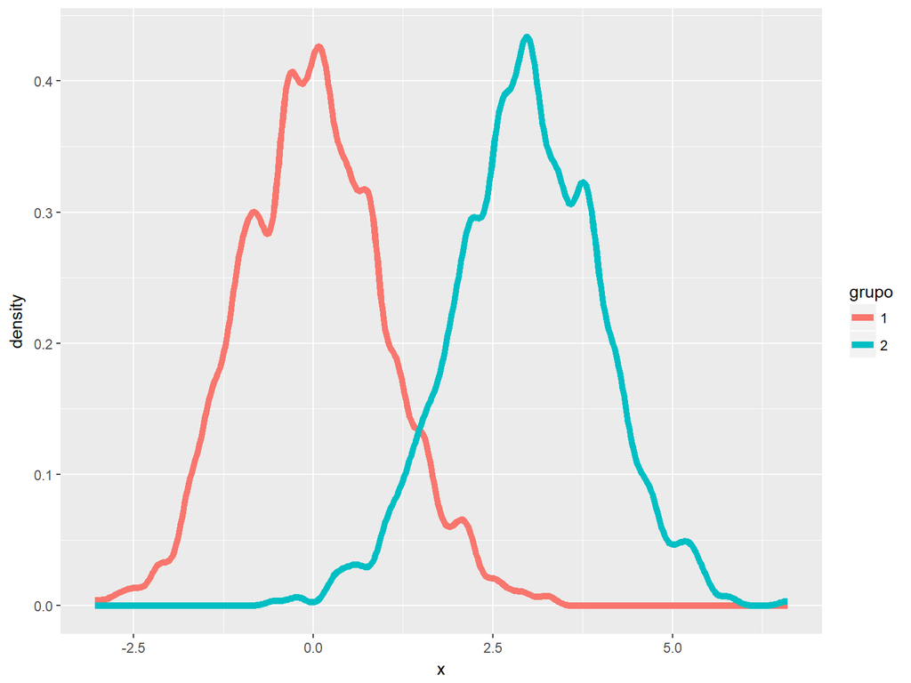

```r
ggplot(mix2norm, aes(x=x, color = grupo)) +
  stat_density(adjust=1/2, size=2, position = "identity", geom = "line")
```

## Escalas

Determina cuál valor de entrada mapea a qué estética específica. Se escribe usando `scale`. Hay de todo:

- `continous`
- `logarithmic`
- `values to shapes`
- `what limits`
- `what labels`
- `what marks`

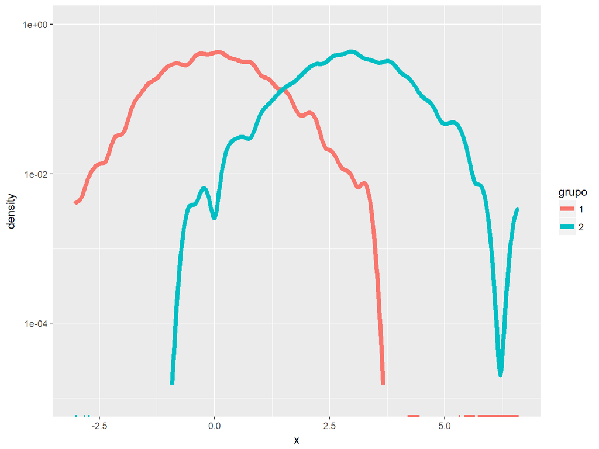

```r
ggplot(mix2norm, aes(x=x, color = grupo)) +
  stat_density(adjust=1/2, size=2, position ="identity", geom ="line") +
  scale_y_log10(limits = c(1e-5,1))
```

## Coordenadas

Te permite especificar las posiciones de las cosas y cómo mapean a las posiciones en la pantalla. Antes todo era entorno a cómo le dices las cosas a `R` pero también importa cómo las ves. Coordenadas distintas pueden afectar a los objetos geométricos. Ejemplos:

- `cartesian`
- `polar`
- `map-projection`

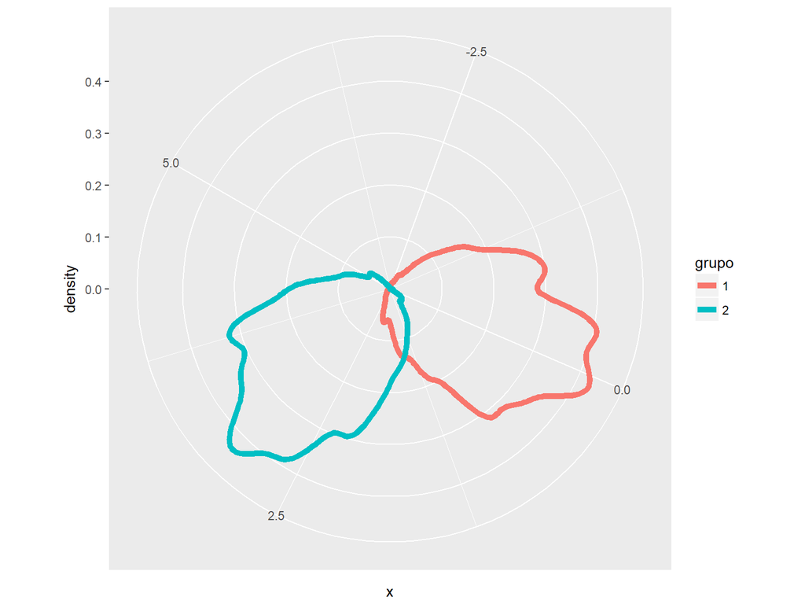

```r
ggplot(mix2norm, aes(x = x, color = grupo)) +
  stat_density(adjust = 1/2, size = 2, position = "identity", geom = "line") +
  coord_polar()
```

## Facetas

Permite arreglar diferentes gráficas en un grid o panel.

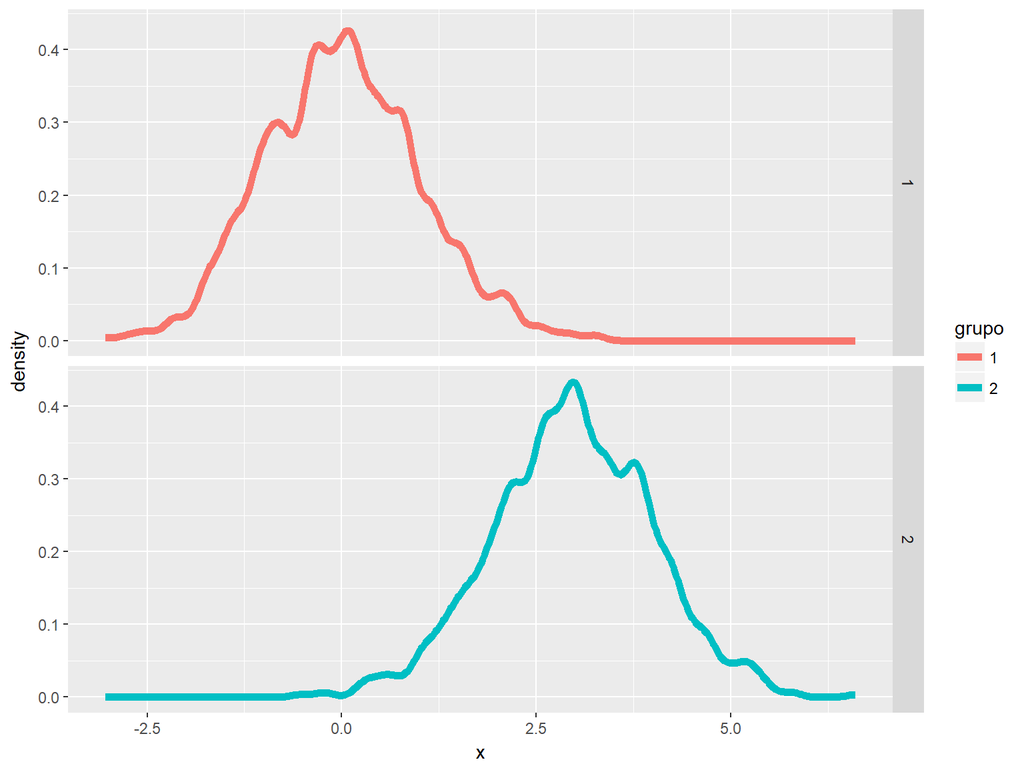

```r
ggplot(mix2norm, aes(x = x, color = grupo)) +
  stat_density(adjust = 1/2, size = 2, position = "identity", geom = "line") +
  facet_grid(grupo ~ .)
```

Ve el help de `facet_wrap`

# Ejercicio - iris

```r
iris
```

```
##     Sepal.Length Sepal.Width Petal.Length Petal.Width    Species
## 1            5.1         3.5          1.4         0.2     setosa
## 2            4.9         3.0          1.4         0.2     setosa
## 3            4.7         3.2          1.3         0.2     setosa
## 4            4.6         3.1          1.5         0.2     setosa
## 5            5.0         3.6          1.4         0.2     setosa
## 6            5.4         3.9          1.7         0.4     setosa
## 7            4.6         3.4          1.4         0.3     setosa
## 8            5.0         3.4          1.5         0.2     setosa
## 9            4.4         2.9          1.4         0.2     setosa
## 10           4.9         3.1          1.5         0.1     setosa
## 11           5.4         3.7          1.5         0.2     setosa
## 12           4.8         3.4          1.6         0.2     setosa
## 13           4.8         3.0          1.4         0.1     setosa
## 14           4.3         3.0          1.1         0.1     setosa
```

[output cut: 136 more lines]

1. Realiza un histograma de `Petal.Length`.
2. Realiza una grafica de puntos con `Petal.Length` en el eje x y `Petal.Width` en el eje y.
3. Usa la grafica en 2 y agrega la variable `species` como color en la estetica.
4. Cambia la posicion de la leyenda abajo del grafico. Hint: agrega `theme`, con el parametro `legend.position = 'bottom')`.

```r
## Respuestas
```

# Variables continuas

hay muchas maneras de visualizar variables continuas.

Nos enfocaremos en dos:

- Boxplots (Diagrama de caja y brazo)
- Histogramas

## Características a buscar

- **Asimetría** Distribuciones simétricas o sesgadas hacia algún lado (distribuciones de ingreso).
- *Outliers* Valores que están muy lejanos al resto de las observaciones, ojo estos pueden contener información valiosa.
- **Multimodalidad** En caso que haya más de una “joroba” en la distribución de los valores.
- **Gaps** Puede ser natural que no haya un área del rango de las variables (calificaciones de exámenes).
- **Amontonamiento (heaping)** Hay veces que por facilidad los valores se acumulan en un mismo valor particular, o especial. (Hora denuncias)
- **Redondeo** Registro de valores redondeados (edad)
- **Imposibles** Registro de valores que no son posibles (Edades negativas)
- **Errores** Registro incorrecto de valores. (edades de 99 anyone ¿?)

Las visualizaciones como los histogramas y los boxplots nos ayudan a entender estas características, sin embargo reitero que se requiere también un análisis estadístico de los valores.

De las estadísticas que describen a una vriable probablemente la media es la medida más común y usada para describir los valores, y usualmente para hacer comparaciones de medias se usa bastante la prueba $t$. La prueba $t$ depende del supuesto que la variable es normal, aunque este supuesto no es tan riguroso y hay maneras de datle la vuelta; esto es para explicar el hecho que también hay que hacer pruebas de normalidad (léase qq-plots, por ejemplo).

## Ejemplos - datos de Pima

```r
library(gridExtra)
data(Pima.tr2, package="MASS")
tbl_df(Pima.tr2)
```

```
## # A tibble: 300 x 8
##    npreg   glu    bp  skin   bmi   ped   age type
##  * <int> <int> <int> <int> <dbl> <dbl> <int> <fct>
##  1     5    86    68    28  30.2 0.364    24 No
##  2     7   195    70    33  25.1 0.163    55 Yes
##  3     5    77    82    41  35.8 0.156    35 No
##  4     0   165    76    43  47.9 0.259    26 No
##  5     0   107    60    25  26.4 0.133    23 No
##  6     5    97    76    27  35.6 0.378    52 Yes
##  7     3    83    58    31  34.3 0.336    25 No
##  8     1   193    50    16  25.9 0.655    24 No
##  9     3   142    80    15  32.4 0.200    63 No
## 10     2   128    78    37  43.3 1.22     31 Yes
## # ... with 290 more rows
```

### Histograma

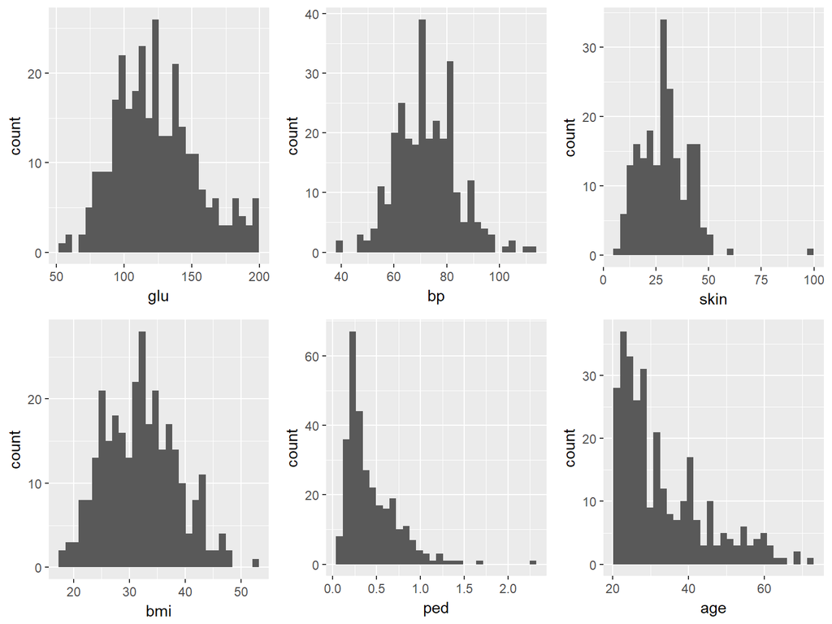

```r
h1 <- ggplot(Pima.tr2, aes(glu)) + geom_histogram()
h2 <- ggplot(Pima.tr2, aes(bp)) + geom_histogram()
h3 <- ggplot(Pima.tr2, aes(skin)) + geom_histogram()
h4 <- ggplot(Pima.tr2, aes(bmi)) + geom_histogram()
h5 <- ggplot(Pima.tr2, aes(ped)) + geom_histogram()
h6 <- ggplot(Pima.tr2, aes(age)) + geom_histogram()
grid.arrange(h1, h2, h3, h4, h5, h6, nrow=2)
```

Las distribuciones de variables plasma, presión arterial y bmi parecen ser simétricas, *skin* tiene algunos outliers, la distribucion de *ped* se ve sesgada y con algunos outliers. Podemos ver también que los grupos de edad son jóvenes.

### Boxplot

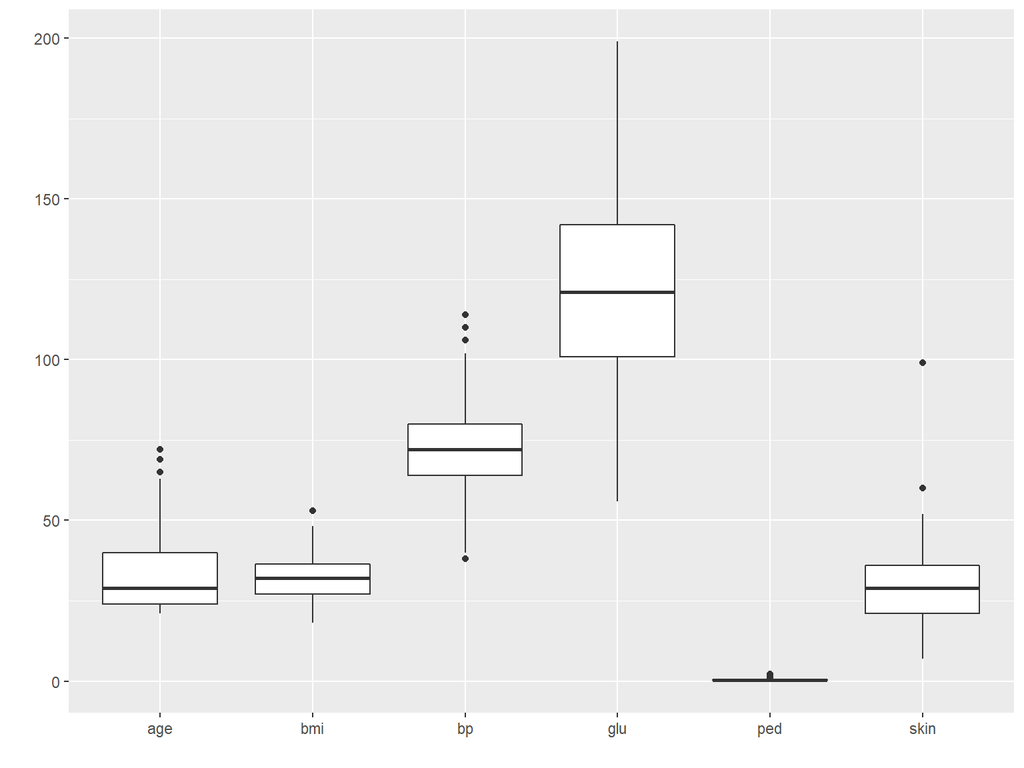

```r
library(dplyr)
PimaV <- select(Pima.tr2, glu:age) %>%
  gather(key = "variable", value = "valor")

ggplot(PimaV, aes(x = variable, y = valor)) +
  geom_boxplot() +
  xlab("") + ylab("")
```

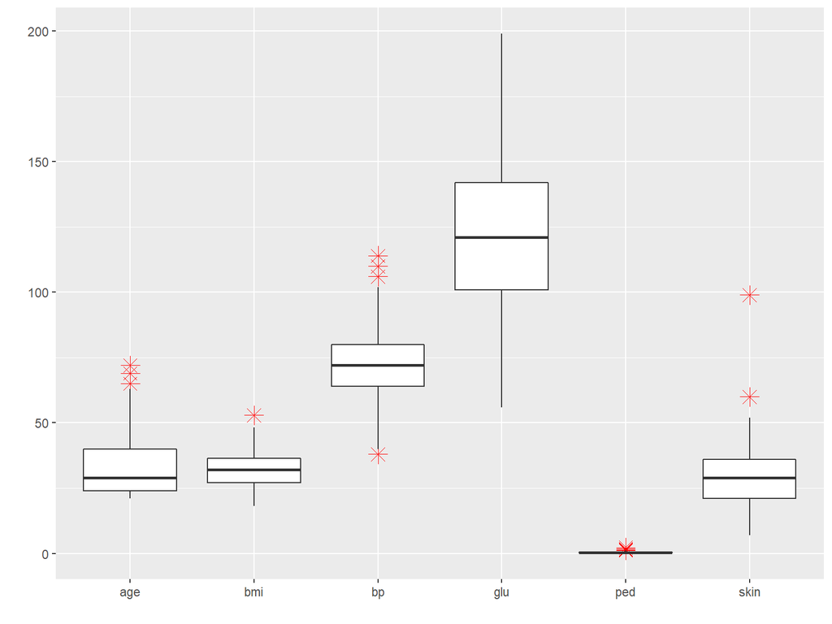

```r
# Cambiamoso el color, forma y tamano de los outliers
ggplot(PimaV, aes(x = variable, y = valor)) +
  geom_boxplot(outlier.colour="red", outlier.shape=8,
                outlier.size=4) +
  xlab("") + ylab("")
```

## Datos de Pearson

Tomaremos los datos de Karl Pearson, que contiene 1078 alturas apareadas de padres e hijos. Grafiquémoslos en histogramas para entender cómo se ven y en este caso nos interesará la normalidad de las variables.

### Histogramas y densidades

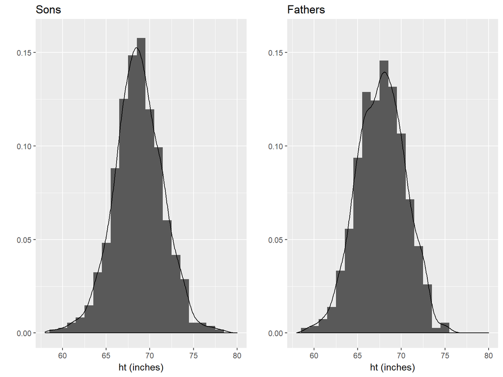

```r
data(father.son, package="UsingR")
c2 <- ggplot(father.son, aes(sheight)) +
             geom_histogram(aes(y = ..density..), binwidth=1) +
             geom_density() + xlim(58, 80) + ylim(0, 0.16) +
             xlab("ht (inches)") + ylab("") + ggtitle("Sons")
p2 <- ggplot(father.son, aes(fheight)) +
             geom_histogram(aes(y = ..density..), binwidth=1) +
             geom_density() + xlim(58, 80) + ylim(0, 0.16) +
             xlab("ht (inches)") + ylab("") +
             ggtitle("Fathers")
grid.arrange(c2, p2, nrow = 1)
```

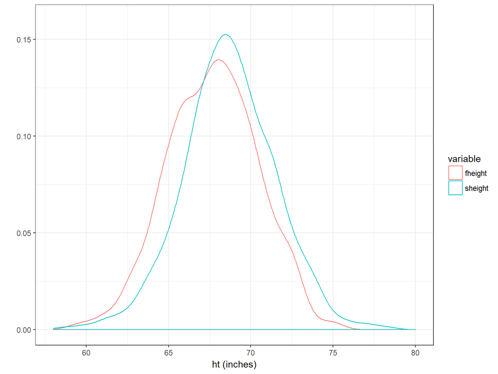

```r
ggplot(father.son %>% gather(key = "variable", value = "altura"), aes(altura, color = variable)) +
             # geom_histogram(aes(y = ..density..), binwidth=1) +
             geom_density() + xlim(58, 80) + ylim(0, 0.16) +
             xlab("ht (inches)") + ylab("") + theme_bw()
```

### qq-plot

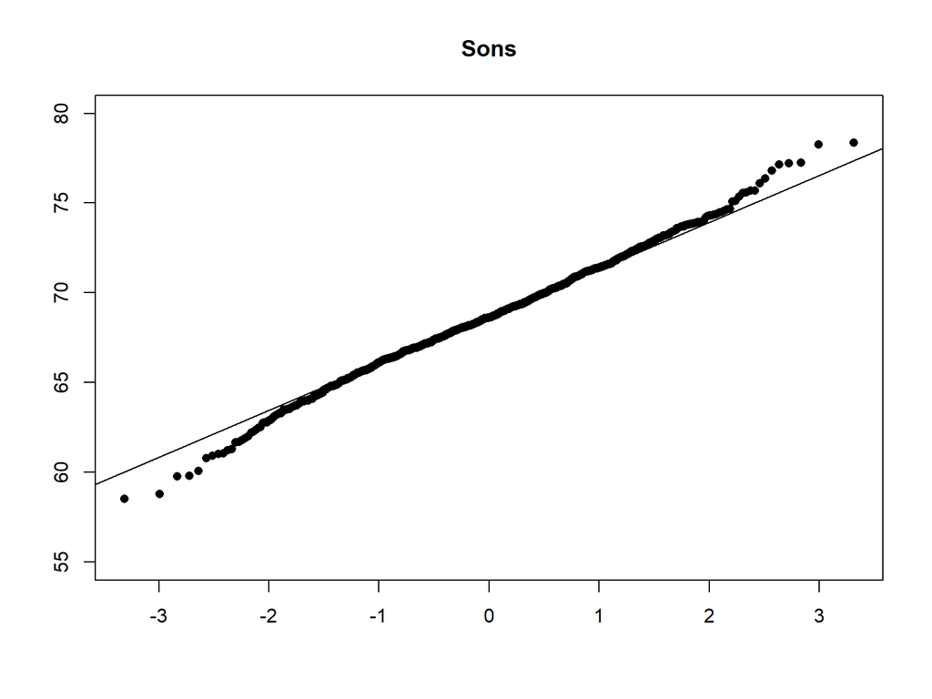

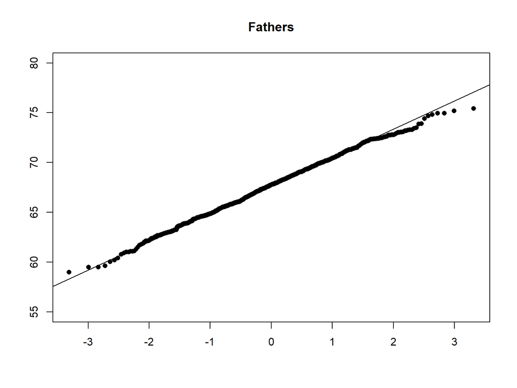

```r
with(father.son, {
     qqnorm(sheight, main="Sons", xlab="",
            ylab="", pch=16, ylim=c(55,80))
     qqline(sheight)
     qqnorm(fheight, main="Fathers", xlab="",
            ylab="", pch=16, ylim=c(55,80))
     qqline(fheight)})
```

# Variables categoricas

## Barras

Experimento de uso de aspirinas después de un infarto a miocardio para detener la muerte de los pacientes.

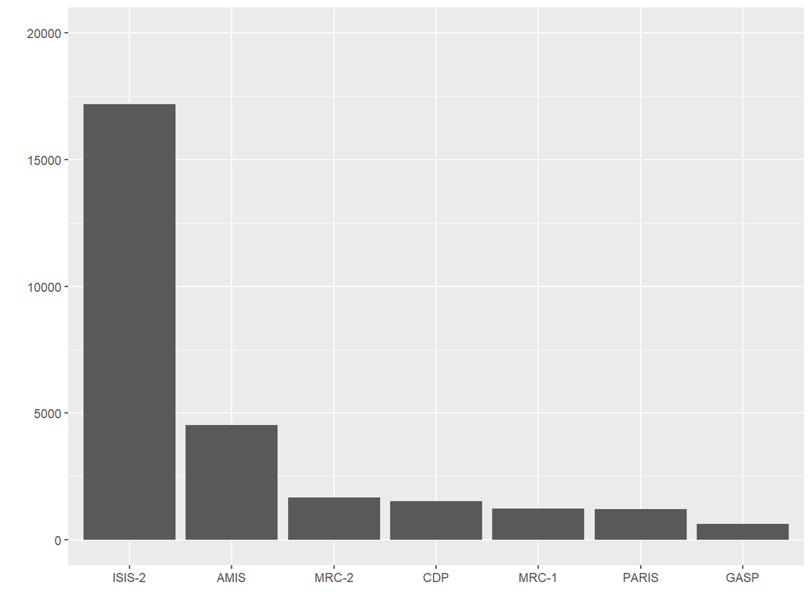

```r
data(Fleiss93, package="meta")
Fleiss93 <- within(Fleiss93, {
                   total <- n.e + n.c
                   st <- reorder(study, -(total)) })
ggplot(Fleiss93, aes(st, total)) + geom_bar(stat="identity") +
       xlab("") + ylab("") + ylim(0,20000)
```

Un experimento contiene una concentración muy importante de los experimentos por lo que si agrupamos todos los que contengan menos de 2000 individuos, tenemos el siguiente gráfico:

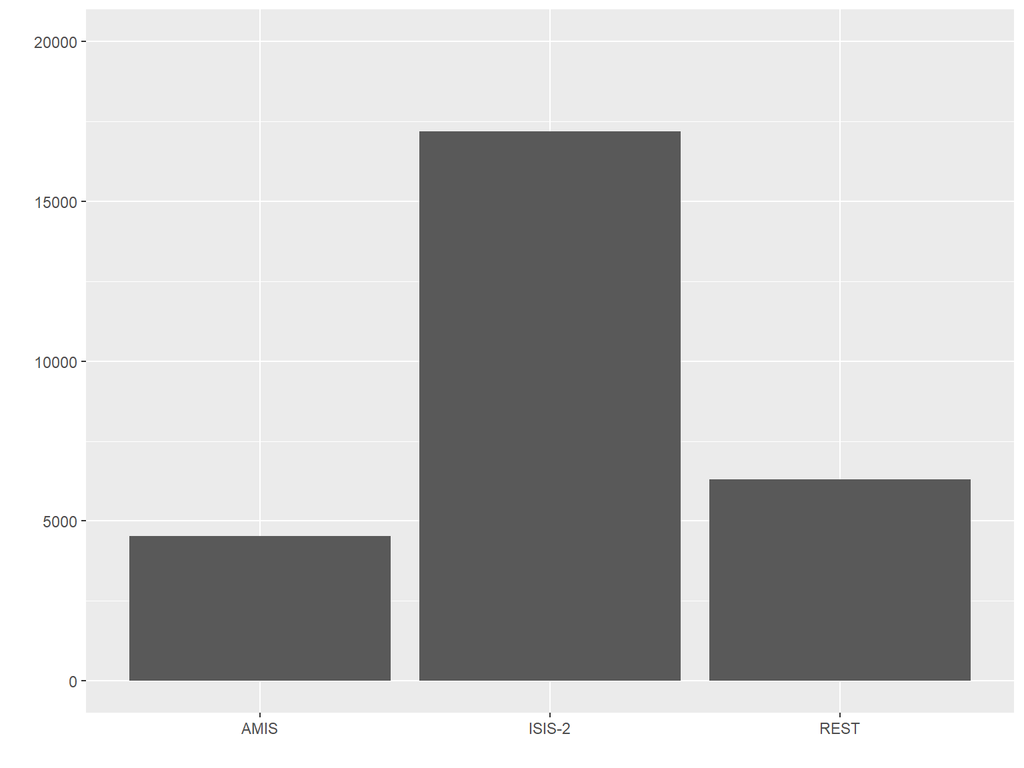

```r
Fleiss93 <- within(Fleiss93, st1 <- as.character(study) )
Fleiss93 <- Fleiss93 %>% mutate(st1 = ifelse(total>2000,st1, "REST"))
ggplot(Fleiss93, aes(st1, total)) + geom_bar(stat="identity") +
       xlab("") + ylab("") + ylim(0,20000)
```

Si agrupamos todos los estudios menores a 2000 individuos, se tiene otro tipo de visualización mucho más clara y también se entiende bastante claramente el hecho que el experimento ISIS-2 contiene mucha más poblacioón que todos los demás.

## Titanic

Tener escalas iguales importa

si hacemos los distintos gráficos a misma escala con distintas vriables tenemos una historia más interesante que sólo el conteo de muertes:

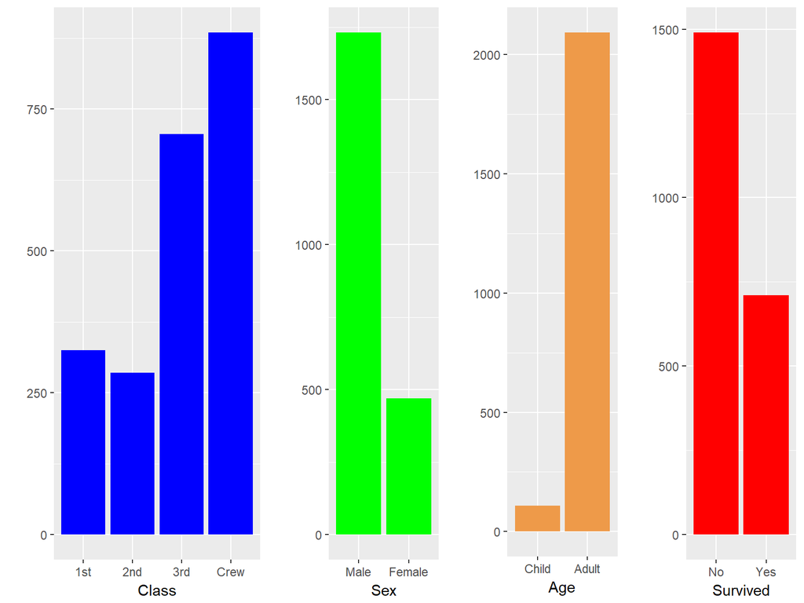

```r
library(gridExtra)
Titanic1 <- data.frame(Titanic)

p <- ggplot(Titanic1, aes(weight=Freq)) +
            ylab("")
cs <- p + aes(Class) + geom_bar(fill="blue")
sx <- p + aes(Sex) + geom_bar(fill="green")
ag <- p + aes(Age) + geom_bar(fill="tan2")
su <- p + aes(Survived) + geom_bar(fill="red")
grid.arrange(cs, sx, ag, su, nrow=1, widths=c(3, 2, 2, 2))
```

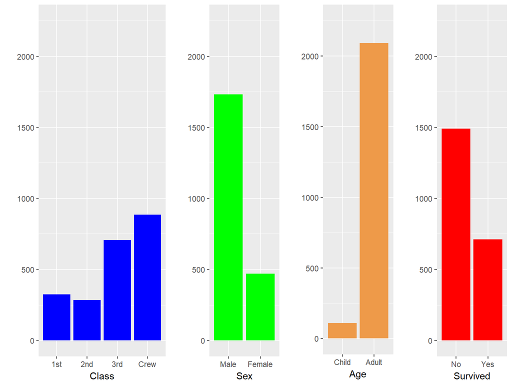

```r
p <- ggplot(Titanic1, aes(weight=Freq)) +
            ylab("") + ylim(0,2250)
cs <- p + aes(Class) + geom_bar(fill="blue")
sx <- p + aes(Sex) + geom_bar(fill="green")
ag <- p + aes(Age) + geom_bar(fill="tan2")
su <- p + aes(Survived) + geom_bar(fill="red")
grid.arrange(cs, sx, ag, su, nrow=1, widths=c(3, 2, 2, 2))
```

# Ejercicio - SKI

```r
data(SpeedSki, package = "GDAdata")
tbl_df(SpeedSki)
```

```
## # A tibble: 91 x 10
##     Rank   Bib FIS.Code Name      Year Nation Speed Sex   Event no.of.runs
##    <int> <int>    <int> <fct>    <int> <fct>  <dbl> <fct> <fct>      <int>
##  1     1    61     7039 ORIGONE~  1979 ITA      212 Male  Spee~          4
##  2     2    59     7078 ORIGONE~  1987 ITA      210 Male  Spee~          4
##  3     3    66   190130 MONTES ~  1985 FRA      210 Male  Spee~          4
##  4     4    57     7178 SCHROTT~  1979 AUT      210 Male  Spee~          4
##  5     5    69   510089 MAY Phi~  1970 SUI      209 Male  Spee~          4
##  6     6    75     7204 BILLY L~  1993 FRA      208 Male  Spee~          4
##  7     7    67     7053 PERSSON~  1975 SWE      208 Male  Spee~          4
##  8     8    58     7170 BILLY S~  1991 FRA      208 Male  Spee~          4
##  9     9    62     7230 CERMAK ~  1980 CZE      207 Male  Spee~          4
## 10    10    56     7055 JANSSON~  1982 SWE      207 Male  Spee~          4
## # ... with 81 more rows
```

1. Utiliza la grafica base

`ggplot(SpeedSki, aes(x=Speed, fill=Sex)) + geom_histogram()`

Revisa el warning. Cambia el binwidth para que deje de mostrarte una advertencia.

2. Cambia los limites de la grafica agregando `xlim` y definiendo un dominio.
3. Agrega etiquetas al eje x y y (usa `xlab` y `ylab`)
4. Agrega una faceta para la variable `Sex`.
5. Elimina la leyenda.
6. Haz un `facet_grid` con las variables `Sex` y `Event`.

```r
## Respuestas
```

# Extra

## Líneas y suavizado.

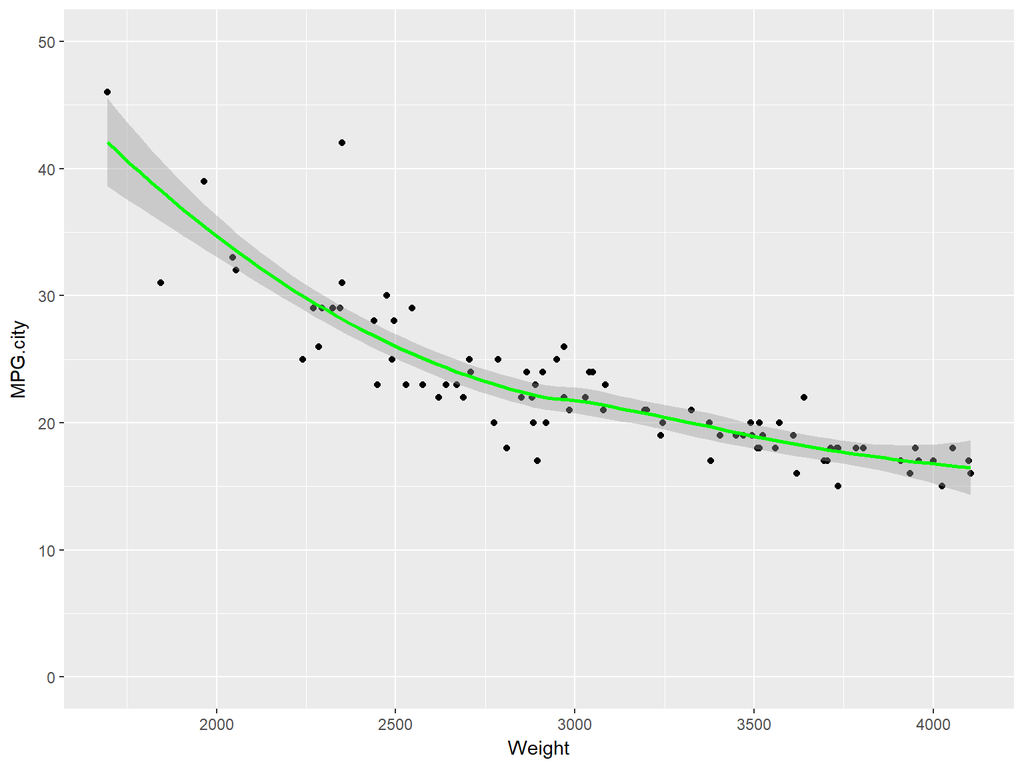

```r
data(Cars93, package="MASS")
ggplot(Cars93, aes(Weight, MPG.city)) + geom_point() +
       geom_smooth(colour="green") + ylim(0,50)
```

Vemos cómo conforme aumenta el peso las millas por galón tieneden a disminuír, (autos más grandes usan más combustible)

## Alturas de las personas

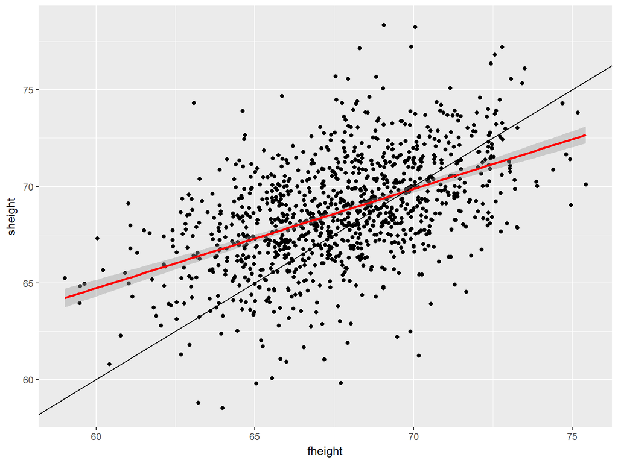

```r
data(father.son, package="UsingR")
ggplot(father.son, aes(fheight, sheight)) + geom_point() +
       geom_smooth(method="lm", colour="red") +
       geom_abline(slope=1, intercept=0)
```

Esto nos ayuda a ver que puede que haya una buena relacioń entre las variables, por lo que pintamos la línea $y=x$, para comparar. Ahora, veamos

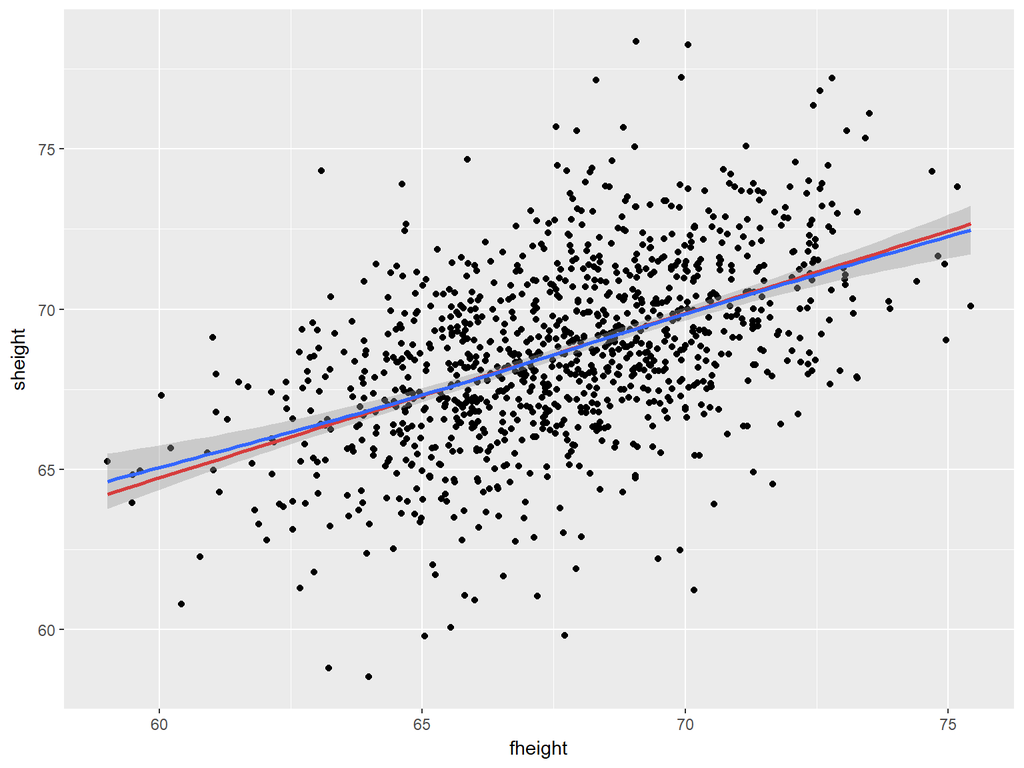

```r
data(father.son, package="UsingR")
ggplot(father.son, aes(fheight, sheight)) + geom_point() +
       geom_smooth(method="lm", colour="red", se=FALSE) +
       stat_smooth()
```

## Grupos de categorías

Filtremos por grupos de atletas, hombres y mujeres.

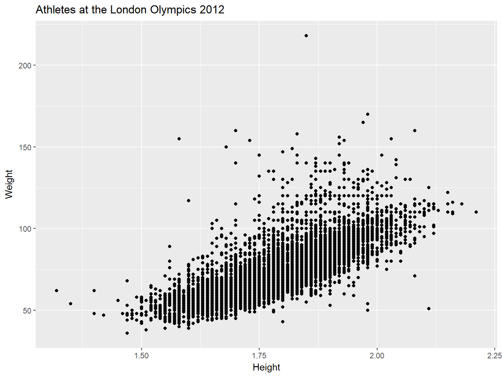

```r
data(oly12, package="VGAMdata")
ggplot(oly12, aes(Height, Weight)) + geom_point() +
       ggtitle("Athletes at the London Olympics 2012")
```

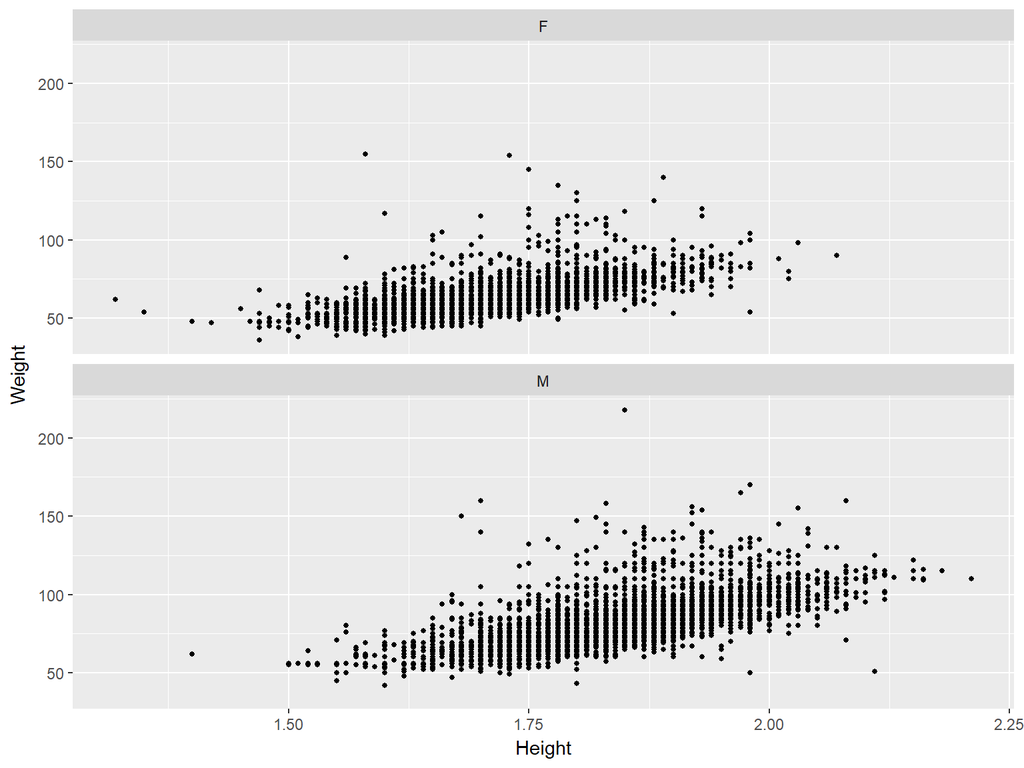

```r
ggplot(oly12, aes(Height,Weight))+geom_point(size=1)+facet_wrap(~Sex,ncol=1)
```

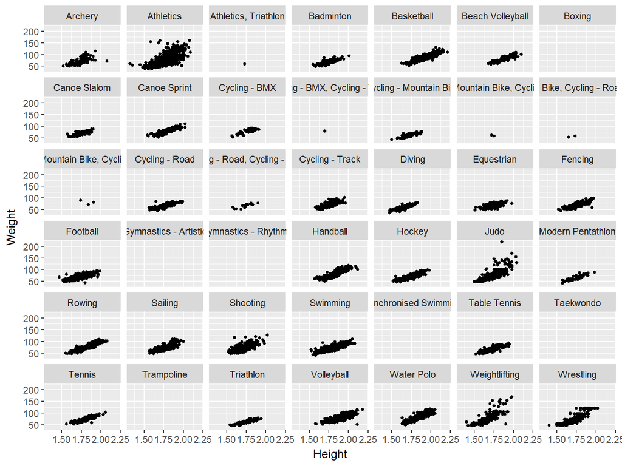

```r
oly125 <- mutate(oly12,Sport=abbreviate(Sport,12))
ggplot(oly12, aes(Height,Weight))+geom_point(size=1)+facet_wrap(~Sport)
```